# Report DENV Investigation Cabo-Verde

2024-01-01

[figure not shown]

INSP - IPD Collaboration during DENV epidemic reponse in Cabo verde

## Background DENV epidemic in Cabo-Verde

```
                                      Background DENV epidemic in Cabo-Verde
```

This html file provide the report of the **DENV outbreak investigation in Cabo-Verde** performed by the **IPD in collaboration with INSP**. Following the **implementation of an arboviruses surveillance program**, in Santiago and Sal, benchmarked from 4S network in Senegal https://bio-protocol.org/exchange/minidetail?type=30&id=8720906 a set suspected DENV cases were obtained from 03 samples collected in Santiago in November 03. Samples were sent in November 05 to the WHO collaborating center for confirmatory tests. Performed test lead to the confirmation of **DENV circulation** ; Cases were reported to WHO by Cabo verdian MOH in 07 November 2023 https://www.governo.cv/ministerio-da-saude-confirma-2-casos-confirmados-de-dengue-no-pais/. In 28 Novemebr the INSP sent a requeste to IPD to set up local DENV serotyping and Genomic surveillance at INSP virology lab located in Augustino Neto Hospital. The first 11 viral genomes were obtained at 30 November.

Some readings about DENV-3 in Africa https://www.ncbi.nlm.nih.gov/pmc/articles/PMC10610876/

## Epidemiology

```
                                                   Epidemiology
```

### Epidemic curve per Island

[figure not shown]

The highest number of DENV cases was recorded in Fogo Island.

### Summary Negative vs Positive DENV cases per Island

Since the start of the epidemic a total of 302 suspected dengue cases were processed at the *Virology Lab of INSP*

Table 1: Summary of DENV cases per Island

|  | Negative | Positive |
| --- | --- | --- |
| Fogo | 65 | 147 |
| Maio | 0 | 1 |
| Santiago | 64 | 23 |
| Sao Vicente | 2 | 0 |

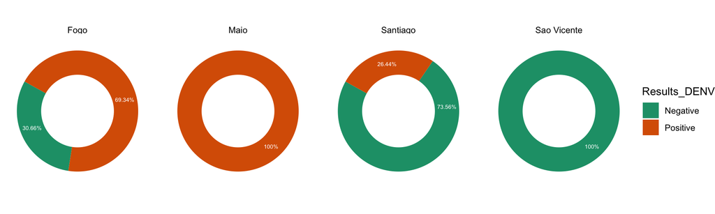

## Genomic surveillance

```
                                                 Genomic surveillance
```

### Wetlab and Bioinformatics

Since the start of the epidemic investigation a set of 80 RNA positive samples were subjected to viral sequencing using protocol previously described by *Dieng and Colleagues* https://www.ncbi.nlm.nih.gov/pmc/articles/PMC10610876/. Basically this protocol use tilling PCR amplicons followed by Nanopore sequencing using Ligation Sequencing Kit. After at least 6h of sequencing raw reads are collected basecalled using guppy and then subjected to genome assembly using genome detective. Consensus sequences are then genotyped and then subjected to phylogenetic analysis. Viral genotyping shows that the epidemic in Cabo Verde is fueled by DENV-3 genotype III.

### Maximum likelyhood (ML) tree of a subset of Cabo verdian DENV sequences

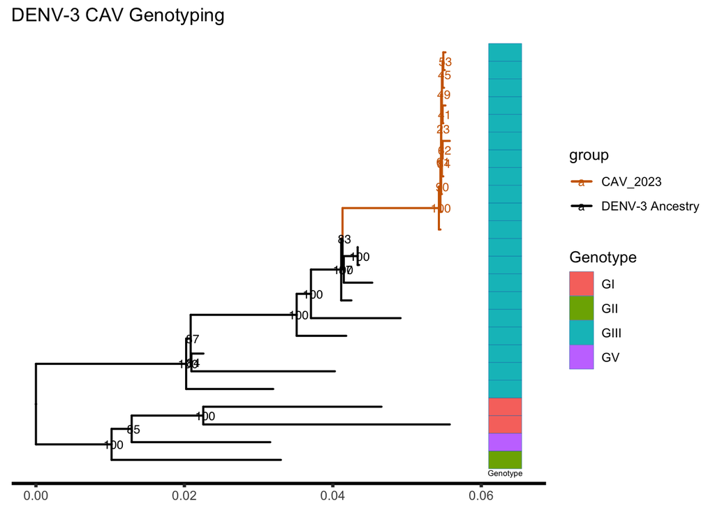

```
                                      Summary and Recomendations
```